# NYPD Shooting Incident Data

L.J.

9/21/2021

## Step 1: Start an Rmd Document

Libary Calls:

```r
library(tidyverse)
library(lubridate)
```

Read data from the main project file

```r
url <- "https://data.cityofnewyork.us/api/views/833y-fsy8/rows.csv?accessType=DOWNLOAD"
data <- read_csv(url)
```

## Step 2: Tidy and Transform Your Data

Check data and data types

```r
summary(data)
```

```
##   INCIDENT_KEY        OCCUR_DATE         OCCUR_TIME           BORO
##  Min.   :  9953245   Length:23568       Length:23568      Length:23568
##  1st Qu.: 55317014   Class :character   Class1:hms        Class :character
##  Median : 83365370   Mode  :character   Class2:difftime   Mode  :character
##  Mean   :102218616                      Mode  :numeric
##  3rd Qu.:150772442
##  Max.   :222473262
##
##     PRECINCT      JURISDICTION_CODE LOCATION_DESC      STATISTICAL_MURDER_FLAG
##  Min.   :  1.00   Min.   :0.0000    Length:23568       Mode :logical
##  1st Qu.: 44.00   1st Qu.:0.0000    Class :character   FALSE:19080
##  Median : 69.00   Median :0.0000    Mode  :character   TRUE :4488
##  Mean   : 66.21   Mean   :0.3323
##  3rd Qu.: 81.00   3rd Qu.:0.0000
##  Max.   :123.00   Max.   :2.0000
##                   NA's   :2
##  PERP_AGE_GROUP       PERP_SEX          PERP_RACE         VIC_AGE_GROUP
##  Length:23568       Length:23568       Length:23568       Length:23568
##  Class :character   Class :character   Class :character   Class :character
##  Mode  :character   Mode  :character   Mode  :character   Mode  :character
##
##
##
##
##    VIC_SEX            VIC_RACE           X_COORD_CD        Y_COORD_CD
##  Length:23568       Length:23568       Min.   : 914928   Min.   :125757
##  Class :character   Class :character   1st Qu.: 999900   1st Qu.:182565
##  Mode  :character   Mode  :character   Median :1007645   Median :193482
##                                        Mean   :1009363   Mean   :207312
##                                        3rd Qu.:1016807   3rd Qu.:239163
##                                        Max.   :1066815   Max.   :271128
##
##     Latitude       Longitude        Lon_Lat
##  Min.   :40.51   Min.   :-74.25   Length:23568
##  1st Qu.:40.67   1st Qu.:-73.94   Class :character
##  Median :40.70   Median :-73.92   Mode  :character
##  Mean   :40.74   Mean   :-73.91
##  3rd Qu.:40.82   3rd Qu.:-73.88
##  Max.   :40.91   Max.   :-73.70
##
```

```r
spec(data)
```

Tidy data by setting data to appropriate types. Most columns converted to factors, OCCUR_DATE is converted to dates, and Lon_Lat is being discarded as it is redundanct. The tidied data is stored as “df”.

```r
df <- data %>%
  mutate(OCCUR_DATE = mdy(OCCUR_DATE)) %>%
  mutate(across(BORO, as.factor)) %>%
  mutate(across(PRECINCT, as.factor)) %>%
  mutate(across(JURISDICTION_CODE, as.factor)) %>%
  mutate(across(LOCATION_DESC, as.factor)) %>%
  mutate(across(PERP_AGE_GROUP, as.factor)) %>%
  mutate(across(PERP_SEX, as.factor)) %>%
  mutate(across(PERP_RACE, as.factor)) %>%
  mutate(across(VIC_AGE_GROUP, as.factor)) %>%
  mutate(across(VIC_SEX, as.factor)) %>%
  mutate(across(VIC_RACE, as.factor)) %>%
  select(-c(Lon_Lat))
```

## Step 3: Add Visualizations and Analysis

### A: Investigation of geographic date (by coordinates)

I want to get a look at where the shooting crimes occurred, and may as well include a class for the markers. In this case, race may be interesting.

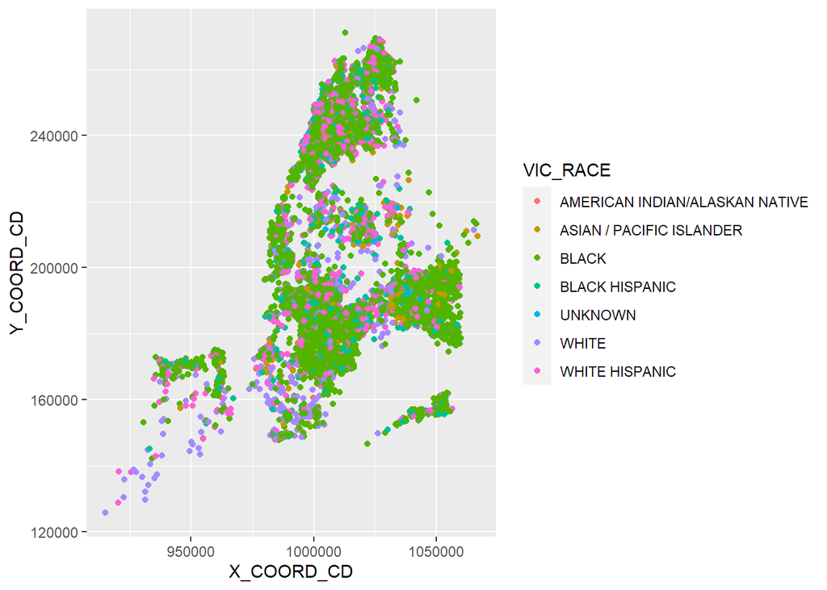

```r
select(df,c(X_COORD_CD,Y_COORD_CD,VIC_RACE)) %>%
  ggplot(aes(x=X_COORD_CD, y=Y_COORD_CD, color=VIC_RACE)) +
  geom_point()
```

We can compare this to a map of the NYPD precincts to better understand what we’re looking at:

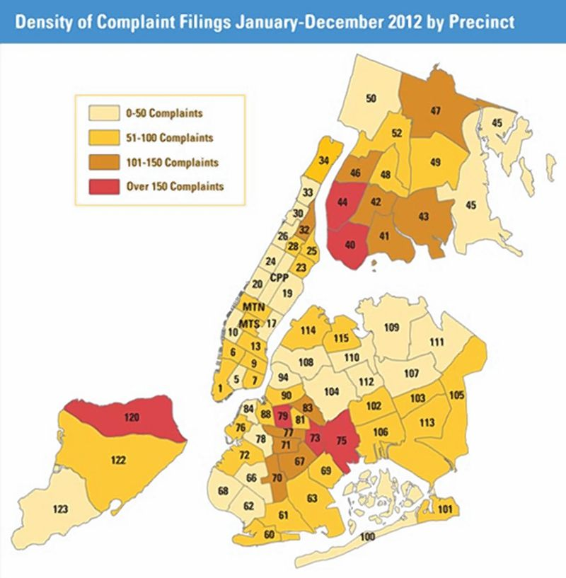

It appears from this visualization that the vast majority of victims were identified as black, and it’s only towards the southwest that we start to see a greater proportion of white victims.

### B: Investigation of annual data

I want to get a look how the shooting incidentc fluctuate over the year. To do so we will group the data by week of the year and plot the average number of incidents.

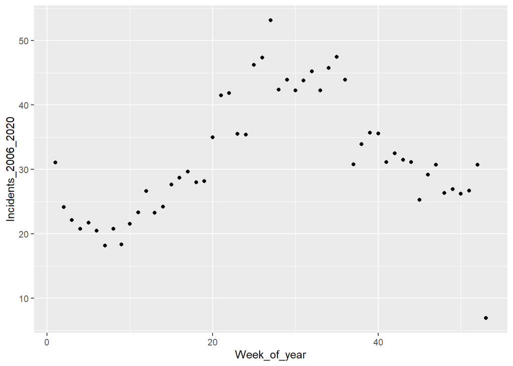

```r
df_weekly <- df %>%
  group_by(Week_of_year = week(OCCUR_DATE)) %>%
  summarise(Incidents_2006_2020 = n()/(2020-2006))

ggplot(df_weekly,aes(x=Week_of_year, y=Incidents_2006_2020)) +
  geom_point()
```

The plot shows a strong peak towards the middle of the year (summer), with a lowest averages roughly in February. We can see that there is data for a 53rd week, representing the last day or two of the year.

I’d like to model this data, and think that removing this 53rd week, should give us a better model. Given the shape of the data and the cyclic nature of what we’re modeling (week 52 and week 1 should maintain a continuous curve) , a straight-line model would be inappropriate, so we will try a cubic model first.

```r
df_weekly <- df_weekly[1:52,]

weekmod3 <- lm(Incidents_2006_2020 ~ poly(Week_of_year,3), df_weekly)
summary(weekmod3)
```

```
##
## Call:
## lm(formula = Incidents_2006_2020 ~ poly(Week_of_year, 3), data = df_weekly)
##
## Residuals:
##     Min      1Q  Median      3Q     Max
## -9.8932 -3.9318 -0.7898  3.1464 13.8913
##
## Coefficients:
##                        Estimate Std. Error t value Pr(>|t|)
## (Intercept)             32.2404     0.7502  42.974  < 2e-16 ***
## poly(Week_of_year, 3)1  22.5892     5.4100   4.175 0.000125 ***
## poly(Week_of_year, 3)2 -43.3865     5.4100  -8.020 2.06e-10 ***
## poly(Week_of_year, 3)3 -17.3429     5.4100  -3.206 0.002398 **
## ---
## Signif. codes:  0 '***' 0.001 '**' 0.01 '*' 0.05 '.' 0.1 ' ' 1
##
## Residual standard error: 5.41 on 48 degrees of freedom
## Multiple R-squared:  0.6572, Adjusted R-squared:  0.6358
## F-statistic: 30.68 on 3 and 48 DF,  p-value: 3.186e-11
```

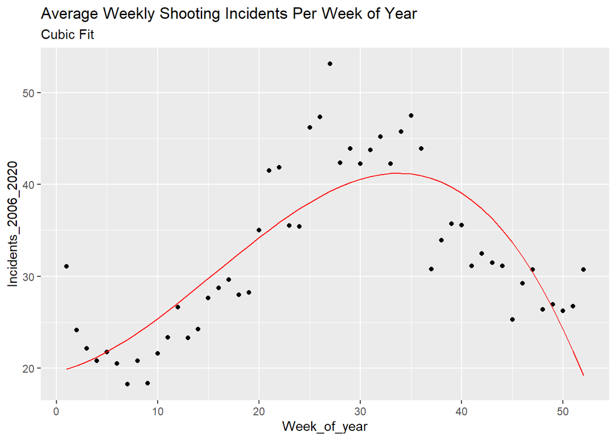

```r
df_weekly %>% mutate(pred=predict(weekmod3)) %>% ggplot() +
  geom_point(aes(x=Week_of_year,y=Incidents_2006_2020)) +
  geom_line(aes(x=Week_of_year,y=pred), color="red") +
  ggtitle("Average Weekly Shooting Incidents Per Week of Year",
          subtitle = "Cubic Fit")
```

Visually, the model doesn’t look like a good fit; the initial curve isn’t steep enough, the middle peak is not reached, and the later curve appears too steep. Looking at the summary, our R-squared value is roughly 0.6, indicated we don’t have a great fit.

Let’s try a higher-degree polynomial (n=5) to see if we can improve the fit.

```r
weekmod5 <- lm(Incidents_2006_2020 ~ poly(Week_of_year,5), df_weekly)
summary(weekmod5)
```

```
##
## Call:
## lm(formula = Incidents_2006_2020 ~ poly(Week_of_year, 5), data = df_weekly)
##
## Residuals:
##     Min      1Q  Median      3Q     Max
## -8.7718 -1.4222  0.0208  1.9073  9.1776
##
## Coefficients:
##                        Estimate Std. Error t value Pr(>|t|)
## (Intercept)             32.2404     0.4567  70.596  < 2e-16 ***
## poly(Week_of_year, 5)1  22.5892     3.2932   6.859 1.48e-08 ***
## poly(Week_of_year, 5)2 -43.3865     3.2932 -13.174  < 2e-16 ***
## poly(Week_of_year, 5)3 -17.3429     3.2932  -5.266 3.58e-06 ***
## poly(Week_of_year, 5)4  29.9302     3.2932   9.088 7.77e-12 ***
## poly(Week_of_year, 5)5   3.1867     3.2932   0.968    0.338
## ---
## Signif. codes:  0 '***' 0.001 '**' 0.01 '*' 0.05 '.' 0.1 ' ' 1
##
## Residual standard error: 3.293 on 46 degrees of freedom
## Multiple R-squared:  0.8783, Adjusted R-squared:  0.865
## F-statistic: 66.38 on 5 and 46 DF,  p-value: < 2.2e-16
```

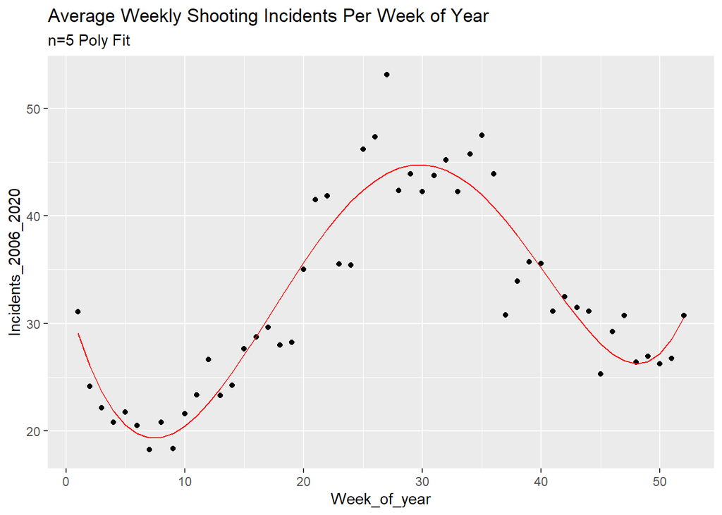

```r
df_weekly %>% mutate(pred=predict(weekmod5)) %>% ggplot() +
  geom_point(aes(x=Week_of_year,y=Incidents_2006_2020)) +
  geom_line(aes(x=Week_of_year,y=pred), color="red") +
  ggtitle("Average Weekly Shooting Incidents Per Week of Year",
          subtitle = "n=5 Poly Fit")
```

This model is a much better fit, with an R-value approaching 0.9. However, with such a high degree polynomial, it’s very possible we’re overfitting the data. Further, when we consider Week 52 being followed by the next year’s Week 1, we can see a disconituity and that we haven’t established a pattern.

A sinusoidal model should give us something more cyclical and one that may fit our data very well.

```r
xc<-cos(2*pi*df_weekly$Week_of_year/52)
xs<-sin(2*pi*df_weekly$Week_of_year/52)
#fit.lm <- lm(temperature~xc+xs)
weekmod_sin <- lm(Incidents_2006_2020 ~ xc+xs, df_weekly)
summary(weekmod_sin)
```

```
##
## Call:
## lm(formula = Incidents_2006_2020 ~ xc + xs, data = df_weekly)
##
## Residuals:
##     Min      1Q  Median      3Q     Max
## -9.7398 -2.3271 -0.5475  1.9759 10.7775
##
## Coefficients:
##             Estimate Std. Error t value Pr(>|t|)
## (Intercept)  32.2404     0.5524  58.369  < 2e-16 ***
## xc           -9.4460     0.7812 -12.092 2.55e-16 ***
## xs           -6.2049     0.7812  -7.943 2.33e-10 ***
## ---
## Signif. codes:  0 '***' 0.001 '**' 0.01 '*' 0.05 '.' 0.1 ' ' 1
##
## Residual standard error: 3.983 on 49 degrees of freedom
## Multiple R-squared:  0.8103, Adjusted R-squared:  0.8026
## F-statistic: 104.7 on 2 and 49 DF,  p-value: < 2.2e-16
```

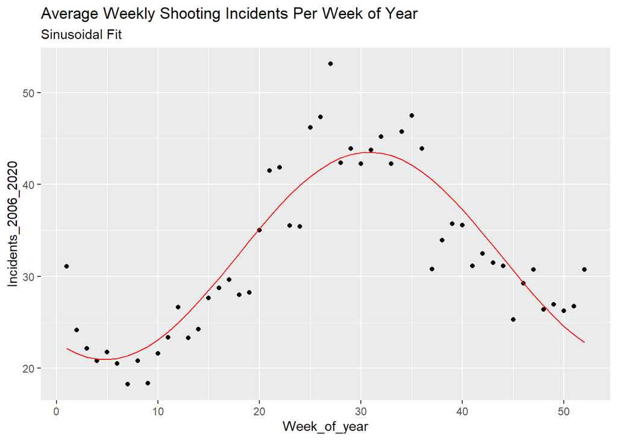

```r
df_weekly %>% mutate(pred=predict(weekmod_sin)) %>% ggplot() +
  geom_point(aes(x=Week_of_year,y=Incidents_2006_2020)) +
  geom_line(aes(x=Week_of_year,y=pred), color="red") +
  ggtitle("Average Weekly Shooting Incidents Per Week of Year",
          subtitle = "Sinusoidal Fit")
```

This final model is definitely a big improvement over the first two. While the R-Value is lower, at 0.8 is still proves a reasonable match.

The model does seem like somewhat of an over-simplification though. A proper time-series analysis could hopefully give us something more meaningful (though that would be outside the scope of this assignment).

## Step 4: Add Bias Identification

In my first visualizations, although I didn’t have any geographic preconceptions, I was struck by the apparent over-representation of black victims in the plot. Had I pursued that line of investigation further, I would have looked to better represent that as a dot plot could have introduced bias when drawing one class over another. It would have made sense to look at racial proportions per precinct and to compare it with external demographic date not included in this dataset.

When approaching the seasonal investigation, I did come in with some biases. I expected summer incidents to skew higher than winter and although this was born out in the visualization, the peaks came later in the year than expected. In my analysis I didn’t look at the years on an individual basis, and doing so could highlight if there were any extreme periods of time that could skew the data. A proper time-series analysis would probably be in order.